# Exploring Pandas with NYC Flights Dataset

R users will recognize this famous dataset as a favorite of Hadley Wickham, author of dplyr. No matter, we can use it with pandas as well.

This dataset will give us flight delay data from all flights departing from the three NYC airports (JFK, LGA, EWR) in the year 2013.

```python
%matplotlib inline

import pandas as pd
import matplotlib.pyplot as plt
import numpy as np
```

```python
df = pd.read_csv('../data/nycflights13/flights.csv.gz')
```

```python
df
```

|  | year | month | day | dep_time | sched_dep_time | dep_delay | arr_time | sched_arr_time | arr_delay | carrier | flight | tailnum | origin | dest | air_time | distance | hour | minute | time_hour |
| --- | --- | --- | --- | --- | --- | --- | --- | --- | --- | --- | --- | --- | --- | --- | --- | --- | --- | --- | --- |
| 0 | 2013 | 1 | 1 | 517.0 | 515 | 2.0 | 830.0 | 819 | 11.0 | UA | 1545 | N14228 | EWR | IAH | 227.0 | 1400 | 5 | 15 | 2013-01-01 05:00:00 |
| 1 | 2013 | 1 | 1 | 533.0 | 529 | 4.0 | 850.0 | 830 | 20.0 | UA | 1714 | N24211 | LGA | IAH | 227.0 | 1416 | 5 | 29 | 2013-01-01 05:00:00 |
| 2 | 2013 | 1 | 1 | 542.0 | 540 | 2.0 | 923.0 | 850 | 33.0 | AA | 1141 | N619AA | JFK | MIA | 160.0 | 1089 | 5 | 40 | 2013-01-01 05:00:00 |
| 3 | 2013 | 1 | 1 | 544.0 | 545 | -1.0 | 1004.0 | 1022 | -18.0 | B6 | 725 | N804JB | JFK | BQN | 183.0 | 1576 | 5 | 45 | 2013-01-01 05:00:00 |
| 4 | 2013 | 1 | 1 | 554.0 | 600 | -6.0 | 812.0 | 837 | -25.0 | DL | 461 | N668DN | LGA | ATL | 116.0 | 762 | 6 | 0 | 2013-01-01 06:00:00 |
| 5 | 2013 | 1 | 1 | 554.0 | 558 | -4.0 | 740.0 | 728 | 12.0 | UA | 1696 | N39463 | EWR | ORD | 150.0 | 719 | 5 | 58 | 2013-01-01 05:00:00 |
| 6 | 2013 | 1 | 1 | 555.0 | 600 | -5.0 | 913.0 | 854 | 19.0 | B6 | 507 | N516JB | EWR | FLL | 158.0 | 1065 | 6 | 0 | 2013-01-01 06:00:00 |
| 7 | 2013 | 1 | 1 | 557.0 | 600 | -3.0 | 709.0 | 723 | -14.0 | EV | 5708 | N829AS | LGA | IAD | 53.0 | 229 | 6 | 0 | 2013-01-01 06:00:00 |
| 8 | 2013 | 1 | 1 | 557.0 | 600 | -3.0 | 838.0 | 846 | -8.0 | B6 | 79 | N593JB | JFK | MCO | 140.0 | 944 | 6 | 0 | 2013-01-01 06:00:00 |
| 9 | 2013 | 1 | 1 | 558.0 | 600 | -2.0 | 753.0 | 745 | 8.0 | AA | 301 | N3ALAA | LGA | ORD | 138.0 | 733 | 6 | 0 | 2013-01-01 06:00:00 |
| 10 | 2013 | 1 | 1 | 558.0 | 600 | -2.0 | 849.0 | 851 | -2.0 | B6 | 49 | N793JB | JFK | PBI | 149.0 | 1028 | 6 | 0 | 2013-01-01 06:00:00 |
| 11 | 2013 | 1 | 1 | 558.0 | 600 | -2.0 | 853.0 | 856 | -3.0 | B6 | 71 | N657JB | JFK | TPA | 158.0 | 1005 | 6 | 0 | 2013-01-01 06:00:00 |
| 12 | 2013 | 1 | 1 | 558.0 | 600 | -2.0 | 924.0 | 917 | 7.0 | UA | 194 | N29129 | JFK | LAX | 345.0 | 2475 | 6 | 0 | 2013-01-01 06:00:00 |
| 13 | 2013 | 1 | 1 | 558.0 | 600 | -2.0 | 923.0 | 937 | -14.0 | UA | 1124 | N53441 | EWR | SFO | 361.0 | 2565 | 6 | 0 | 2013-01-01 06:00:00 |
| 14 | 2013 | 1 | 1 | 559.0 | 600 | -1.0 | 941.0 | 910 | 31.0 | AA | 707 | N3DUAA | LGA | DFW | 257.0 | 1389 | 6 | 0 | 2013-01-01 06:00:00 |
| 15 | 2013 | 1 | 1 | 559.0 | 559 | 0.0 | 702.0 | 706 | -4.0 | B6 | 1806 | N708JB | JFK | BOS | 44.0 | 187 | 5 | 59 | 2013-01-01 05:00:00 |
| 16 | 2013 | 1 | 1 | 559.0 | 600 | -1.0 | 854.0 | 902 | -8.0 | UA | 1187 | N76515 | EWR | LAS | 337.0 | 2227 | 6 | 0 | 2013-01-01 06:00:00 |
| 17 | 2013 | 1 | 1 | 600.0 | 600 | 0.0 | 851.0 | 858 | -7.0 | B6 | 371 | N595JB | LGA | FLL | 152.0 | 1076 | 6 | 0 | 2013-01-01 06:00:00 |
| 18 | 2013 | 1 | 1 | 600.0 | 600 | 0.0 | 837.0 | 825 | 12.0 | MQ | 4650 | N542MQ | LGA | ATL | 134.0 | 762 | 6 | 0 | 2013-01-01 06:00:00 |
| 19 | 2013 | 1 | 1 | 601.0 | 600 | 1.0 | 844.0 | 850 | -6.0 | B6 | 343 | N644JB | EWR | PBI | 147.0 | 1023 | 6 | 0 | 2013-01-01 06:00:00 |
| 20 | 2013 | 1 | 1 | 602.0 | 610 | -8.0 | 812.0 | 820 | -8.0 | DL | 1919 | N971DL | LGA | MSP | 170.0 | 1020 | 6 | 10 | 2013-01-01 06:00:00 |
| 21 | 2013 | 1 | 1 | 602.0 | 605 | -3.0 | 821.0 | 805 | 16.0 | MQ | 4401 | N730MQ | LGA | DTW | 105.0 | 502 | 6 | 5 | 2013-01-01 06:00:00 |
| 22 | 2013 | 1 | 1 | 606.0 | 610 | -4.0 | 858.0 | 910 | -12.0 | AA | 1895 | N633AA | EWR | MIA | 152.0 | 1085 | 6 | 10 | 2013-01-01 06:00:00 |
| 23 | 2013 | 1 | 1 | 606.0 | 610 | -4.0 | 837.0 | 845 | -8.0 | DL | 1743 | N3739P | JFK | ATL | 128.0 | 760 | 6 | 10 | 2013-01-01 06:00:00 |
| 24 | 2013 | 1 | 1 | 607.0 | 607 | 0.0 | 858.0 | 915 | -17.0 | UA | 1077 | N53442 | EWR | MIA | 157.0 | 1085 | 6 | 7 | 2013-01-01 06:00:00 |
| 25 | 2013 | 1 | 1 | 608.0 | 600 | 8.0 | 807.0 | 735 | 32.0 | MQ | 3768 | N9EAMQ | EWR | ORD | 139.0 | 719 | 6 | 0 | 2013-01-01 06:00:00 |
| 26 | 2013 | 1 | 1 | 611.0 | 600 | 11.0 | 945.0 | 931 | 14.0 | UA | 303 | N532UA | JFK | SFO | 366.0 | 2586 | 6 | 0 | 2013-01-01 06:00:00 |
| 27 | 2013 | 1 | 1 | 613.0 | 610 | 3.0 | 925.0 | 921 | 4.0 | B6 | 135 | N635JB | JFK | RSW | 175.0 | 1074 | 6 | 10 | 2013-01-01 06:00:00 |
| 28 | 2013 | 1 | 1 | 615.0 | 615 | 0.0 | 1039.0 | 1100 | -21.0 | B6 | 709 | N794JB | JFK | SJU | 182.0 | 1598 | 6 | 15 | 2013-01-01 06:00:00 |
| 29 | 2013 | 1 | 1 | 615.0 | 615 | 0.0 | 833.0 | 842 | -9.0 | DL | 575 | N326NB | EWR | ATL | 120.0 | 746 | 6 | 15 | 2013-01-01 06:00:00 |
| ... | ... | ... | ... | ... | ... | ... | ... | ... | ... | ... | ... | ... | ... | ... | ... | ... | ... | ... | ... |
| 336746 | 2013 | 9 | 30 | 2123.0 | 2125 | -2.0 | 2223.0 | 2247 | -24.0 | EV | 5489 | N712EV | LGA | CHO | 45.0 | 305 | 21 | 25 | 2013-09-30 21:00:00 |
| 336747 | 2013 | 9 | 30 | 2127.0 | 2129 | -2.0 | 2314.0 | 2323 | -9.0 | EV | 3833 | N16546 | EWR | CLT | 72.0 | 529 | 21 | 29 | 2013-09-30 21:00:00 |
| 336748 | 2013 | 9 | 30 | 2128.0 | 2130 | -2.0 | 2328.0 | 2359 | -31.0 | B6 | 97 | N807JB | JFK | DEN | 213.0 | 1626 | 21 | 30 | 2013-09-30 21:00:00 |
| 336749 | 2013 | 9 | 30 | 2129.0 | 2059 | 30.0 | 2230.0 | 2232 | -2.0 | EV | 5048 | N751EV | LGA | RIC | 45.0 | 292 | 20 | 59 | 2013-09-30 20:00:00 |
| 336750 | 2013 | 9 | 30 | 2131.0 | 2140 | -9.0 | 2225.0 | 2255 | -30.0 | MQ | 3621 | N807MQ | JFK | DCA | 36.0 | 213 | 21 | 40 | 2013-09-30 21:00:00 |
| 336751 | 2013 | 9 | 30 | 2140.0 | 2140 | 0.0 | 10.0 | 40 | -30.0 | AA | 185 | N335AA | JFK | LAX | 298.0 | 2475 | 21 | 40 | 2013-09-30 21:00:00 |
| 336752 | 2013 | 9 | 30 | 2142.0 | 2129 | 13.0 | 2250.0 | 2239 | 11.0 | EV | 4509 | N12957 | EWR | PWM | 47.0 | 284 | 21 | 29 | 2013-09-30 21:00:00 |
| 336753 | 2013 | 9 | 30 | 2145.0 | 2145 | 0.0 | 115.0 | 140 | -25.0 | B6 | 1103 | N633JB | JFK | SJU | 192.0 | 1598 | 21 | 45 | 2013-09-30 21:00:00 |
| 336754 | 2013 | 9 | 30 | 2147.0 | 2137 | 10.0 | 30.0 | 27 | 3.0 | B6 | 1371 | N627JB | LGA | FLL | 139.0 | 1076 | 21 | 37 | 2013-09-30 21:00:00 |
| 336755 | 2013 | 9 | 30 | 2149.0 | 2156 | -7.0 | 2245.0 | 2308 | -23.0 | UA | 523 | N813UA | EWR | BOS | 37.0 | 200 | 21 | 56 | 2013-09-30 21:00:00 |
| 336756 | 2013 | 9 | 30 | 2150.0 | 2159 | -9.0 | 2250.0 | 2306 | -16.0 | EV | 3842 | N10575 | EWR | MHT | 39.0 | 209 | 21 | 59 | 2013-09-30 21:00:00 |
| 336757 | 2013 | 9 | 30 | 2159.0 | 1845 | 194.0 | 2344.0 | 2030 | 194.0 | 9E | 3320 | N906XJ | JFK | BUF | 50.0 | 301 | 18 | 45 | 2013-09-30 18:00:00 |
| 336758 | 2013 | 9 | 30 | 2203.0 | 2205 | -2.0 | 2339.0 | 2331 | 8.0 | EV | 5311 | N722EV | LGA | BGR | 61.0 | 378 | 22 | 5 | 2013-09-30 22:00:00 |
| 336759 | 2013 | 9 | 30 | 2207.0 | 2140 | 27.0 | 2257.0 | 2250 | 7.0 | MQ | 3660 | N532MQ | LGA | BNA | 97.0 | 764 | 21 | 40 | 2013-09-30 21:00:00 |
| 336760 | 2013 | 9 | 30 | 2211.0 | 2059 | 72.0 | 2339.0 | 2242 | 57.0 | EV | 4672 | N12145 | EWR | STL | 120.0 | 872 | 20 | 59 | 2013-09-30 20:00:00 |
| 336761 | 2013 | 9 | 30 | 2231.0 | 2245 | -14.0 | 2335.0 | 2356 | -21.0 | B6 | 108 | N193JB | JFK | PWM | 48.0 | 273 | 22 | 45 | 2013-09-30 22:00:00 |
| 336762 | 2013 | 9 | 30 | 2233.0 | 2113 | 80.0 | 112.0 | 30 | 42.0 | UA | 471 | N578UA | EWR | SFO | 318.0 | 2565 | 21 | 13 | 2013-09-30 21:00:00 |
| 336763 | 2013 | 9 | 30 | 2235.0 | 2001 | 154.0 | 59.0 | 2249 | 130.0 | B6 | 1083 | N804JB | JFK | MCO | 123.0 | 944 | 20 | 1 | 2013-09-30 20:00:00 |
| 336764 | 2013 | 9 | 30 | 2237.0 | 2245 | -8.0 | 2345.0 | 2353 | -8.0 | B6 | 234 | N318JB | JFK | BTV | 43.0 | 266 | 22 | 45 | 2013-09-30 22:00:00 |
| 336765 | 2013 | 9 | 30 | 2240.0 | 2245 | -5.0 | 2334.0 | 2351 | -17.0 | B6 | 1816 | N354JB | JFK | SYR | 41.0 | 209 | 22 | 45 | 2013-09-30 22:00:00 |
| 336766 | 2013 | 9 | 30 | 2240.0 | 2250 | -10.0 | 2347.0 | 7 | -20.0 | B6 | 2002 | N281JB | JFK | BUF | 52.0 | 301 | 22 | 50 | 2013-09-30 22:00:00 |
| 336767 | 2013 | 9 | 30 | 2241.0 | 2246 | -5.0 | 2345.0 | 1 | -16.0 | B6 | 486 | N346JB | JFK | ROC | 47.0 | 264 | 22 | 46 | 2013-09-30 22:00:00 |
| 336768 | 2013 | 9 | 30 | 2307.0 | 2255 | 12.0 | 2359.0 | 2358 | 1.0 | B6 | 718 | N565JB | JFK | BOS | 33.0 | 187 | 22 | 55 | 2013-09-30 22:00:00 |
| 336769 | 2013 | 9 | 30 | 2349.0 | 2359 | -10.0 | 325.0 | 350 | -25.0 | B6 | 745 | N516JB | JFK | PSE | 196.0 | 1617 | 23 | 59 | 2013-09-30 23:00:00 |
| 336770 | 2013 | 9 | 30 | NaN | 1842 | NaN | NaN | 2019 | NaN | EV | 5274 | N740EV | LGA | BNA | NaN | 764 | 18 | 42 | 2013-09-30 18:00:00 |
| 336771 | 2013 | 9 | 30 | NaN | 1455 | NaN | NaN | 1634 | NaN | 9E | 3393 | NaN | JFK | DCA | NaN | 213 | 14 | 55 | 2013-09-30 14:00:00 |
| 336772 | 2013 | 9 | 30 | NaN | 2200 | NaN | NaN | 2312 | NaN | 9E | 3525 | NaN | LGA | SYR | NaN | 198 | 22 | 0 | 2013-09-30 22:00:00 |
| 336773 | 2013 | 9 | 30 | NaN | 1210 | NaN | NaN | 1330 | NaN | MQ | 3461 | N535MQ | LGA | BNA | NaN | 764 | 12 | 10 | 2013-09-30 12:00:00 |
| 336774 | 2013 | 9 | 30 | NaN | 1159 | NaN | NaN | 1344 | NaN | MQ | 3572 | N511MQ | LGA | CLE | NaN | 419 | 11 | 59 | 2013-09-30 11:00:00 |
| 336775 | 2013 | 9 | 30 | NaN | 840 | NaN | NaN | 1020 | NaN | MQ | 3531 | N839MQ | LGA | RDU | NaN | 431 | 8 | 40 | 2013-09-30 08:00:00 |

336776 rows × 19 columns

Let us focus on some summary and visualizations that we can do here. Let's start out by finding the average delay by month. We'll also do a matlibplot on it.

```python
mean_delay_by_month = df.groupby(['month'])['arr_delay'].mean()
mean_delay_by_month
```

```
month
1      6.129972
2      5.613019
3      5.807577
4     11.176063
5      3.521509
6     16.481330
7     16.711307
8      6.040652
9     -4.018364
10    -0.167063
11     0.461347
12    14.870355
Name: arr_delay, dtype: float64
```

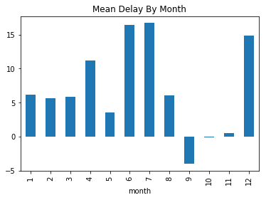

```python
mean_month_plt = mean_delay_by_month.plot(kind='bar', title="Mean Delay By Month")
mean_month_plt
```

Notice that flights in two months actually have negative delay. No doubt airlines "pad" flight times to achieve better results.